# Team 3 R Plots

#### **R plots for pH level of water with respect to Alkalinity**

```
##
## Call:
## lm(formula = North_Site$pH ~ North_Site$Alkalinity)
##
## Residuals:
##      Min       1Q   Median       3Q      Max
## -2.57325 -0.17264  0.03005  0.26956  1.33701
##
## Coefficients:
##                         Estimate Std. Error t value Pr(>|t|)
## (Intercept)            8.1034682  0.1474577  54.955   <2e-16 ***
## North_Site$Alkalinity -0.0001242  0.0005240  -0.237    0.813
## ---
## Signif. codes:  0 '***' 0.001 '**' 0.01 '*' 0.05 '.' 0.1 ' ' 1
##
## Residual standard error: 0.4813 on 262 degrees of freedom
## Multiple R-squared:  0.0002142,  Adjusted R-squared:  -0.003602
## F-statistic: 0.05614 on 1 and 262 DF,  p-value: 0.8129
```

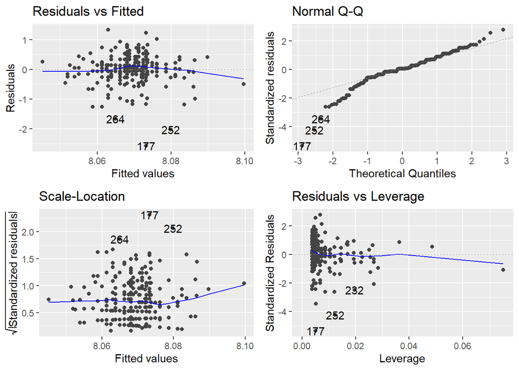

```
## [1] 0.05613819
```

```
## [1] 0.05584194
```

```
## [1] 0.8128924
```

```
## [1] 0.8133776
```

1. **Residual Vs Fitted**: Used to check the linear relationship assumptions. A horizontal line, without distinct patterns is an indication for a linear relationship, which is good. In this case there is no fitted pattern in the residual plot. This suggests that we can assume linear relationship between the predictors and the outcome variables.
2. **Normal Q-Q**: Used to examine whether the residuals are normally distributed. It’s good if residuals points follow the straight dashed line. In this case many observations are far away from the expected line therefore not normally distributed.
3. **Standardized Residual Plot**: The plot shows if residuals are spread equally along the ranges of predictors. It’s good if we see a horizontal line with equally spread points. In this case, this is not the case. It can be seen that the variability (variances) of the residual points is random with the value of the fitted outcome variable, suggesting no non-constant variances in the residuals errors.
4. **Residue Vs Leverage**: Used to identify influential cases, that is extreme values that might influence the regression results when included or excluded from the analysis. In this case the three observations visible as high leverage points and should be well investigated.

## E coli Value for North and West sites

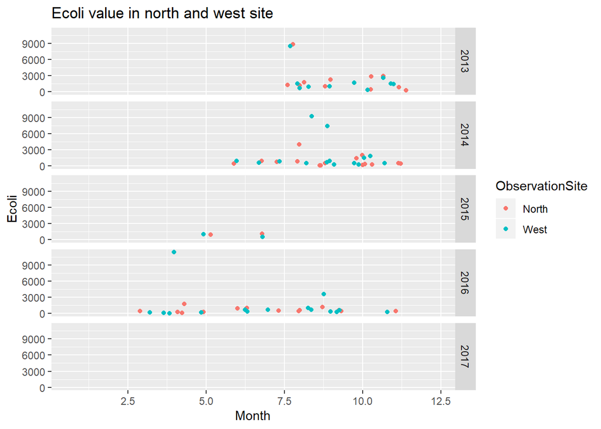

## Precipitation Value for North and West sites

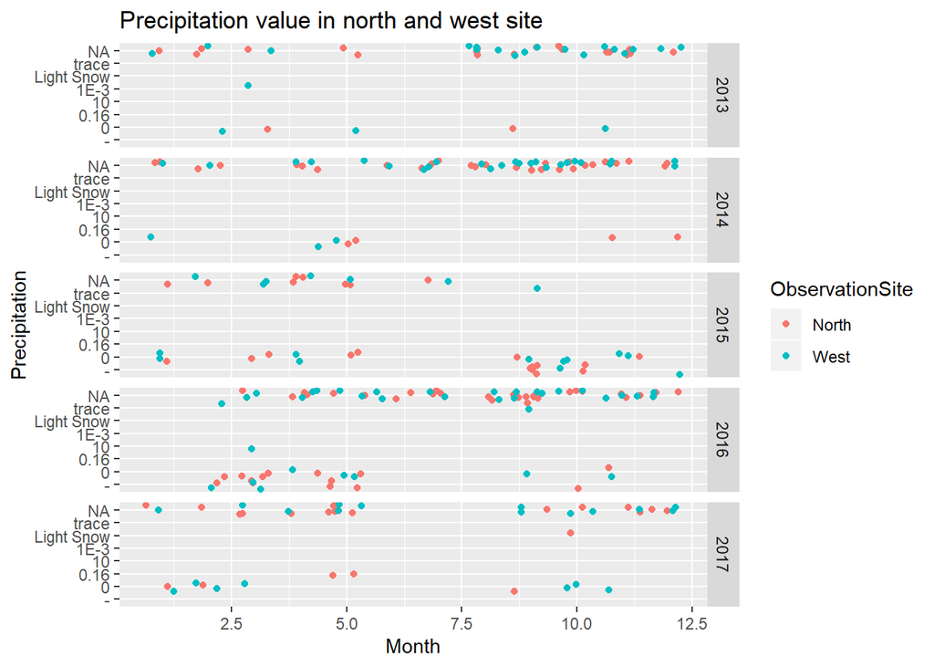